# Exercises and Solutions

A Brief Introduction to Programming with R

Author

Ana Armendariz & Federica Mascolo

Published

September 4, 2026

```r
install.packages(c("dplyr", "ggplot2"))
library(dplyr)
library(ggplot2)
```

# Part I: Background and tools

### Exercise a: setting up a working environment

1. Open RStudio and navigate to your desired working folder
2. Create a new folder called `r_course`
3. Set it as your working directory
4. Create subfolders: `data` and `code`
5. (*) Create a new R Project in the `r_course` folder

**Solution**

```r
dir.create("r_course")
setwd("r_course")
dir.create("data")
dir.create("code")
getwd()
```

R Project: `File > New Project > Existing Directory`, then pick `r_course`.

### Exercise b: R scripts

1. In the R console, type `print("Hello world")`
2. Create a new R script: `File > New File > R Script` (or `Ctrl+Shift+N`)
3. Type the same code in the script and run it using `Ctrl+Enter`

**Solution**

```r
print("Hello world")
```

```
[1] "Hello world"
```

# Part II: First steps and basic concepts

### Exercise a: write a sum function

Write a function that takes a numeric vector as input and returns the sum of the vector’s elements. Test by comparing with built-in `sum()` function.

**Solution**

```r
my_sum <- function(x) {
  total_sum <- 0

  for (value in x) {
    total_sum <- total_sum + value
  }

  return(total_sum)
}

numeric_vector <- c(1, 5, 4, 3)
my_sum(numeric_vector)
```

```
[1] 13
```

```r
sum(numeric_vector)
```

```
[1] 13
```

### Exercise b: robustness and warnings

Test your `my_sum()` function with `numbers2 <- c("1", "2", "3")`. Add error checking to make the function robust.

**Solution**

```r
my_sum <- function(x) {
  if (!is.numeric(x)) {
    warning("The input is not numeric; attempting to convert it.")
    x <- suppressWarnings(as.numeric(x))
  }

  if (anyNA(x)) {
    stop("The input contains values that cannot be converted to numbers.")
  }

  total_sum <- 0

  for (value in x) {
    total_sum <- total_sum + value
  }

  return(total_sum)
}

numbers2 <- c("1", "2", "3")
my_sum(numbers2)
```

```
[1] 6
```

### Exercise c: standard deviation function

Implement a function to compute the standard deviation:

$$\mathrm{SD} = \sqrt{\frac{1}{N-1}\sum_{i=1}^{N}(x_i-\bar{x})^2}$$

**Solution**

```r
my_sd <- function(x) {
  if (!is.numeric(x)) {
    stop("x must be numeric.")
  }

  n <- length(x)
  if (n < 2) {
    stop("x must contain at least two values.")
  }

  x_bar <- mean(x)
  squared_deviations <- (x - x_bar)^2
  sqrt(sum(squared_deviations) / (n - 1))
}

my_sd(numeric_vector)
```

```
[1] 1.707825
```

```r
sd(numeric_vector)
```

```
[1] 1.707825
```

### Exercise d: standard error function

Building on Exercise c, implement:

$$\mathrm{SE}_{\bar{x}} = \frac{\mathrm{SD}}{\sqrt{N}}$$

**Solution**

```r
my_se <- function(x) {
  my_sd(x) / sqrt(length(x))
}

my_se(numeric_vector)
```

```
[1] 0.8539126
```

```r
sd(numeric_vector) / sqrt(length(numeric_vector))
```

```
[1] 0.8539126
```

### Exercise e: t-test

Implement a one-sample t-test function:

$$t = \frac{\bar{x}-\mu_0}{\mathrm{SE}_{\bar{x}}}$$

**Solution**

```r
my_t_test <- function(x, mu_0) {
  (mean(x) - mu_0) / my_se(x)
}

my_t_test(numeric_vector, mu_0 = 3)
```

```
[1] 0.29277
```

```r
unname(t.test(numeric_vector, mu = 3)$statistic)
```

```
[1] 0.29277
```

### Exercise f: Fibonacci sequence

Generate the first 30 Fibonacci numbers where $F_0 = 0$, $F_1 = 1$, and $F_n = F_{n-1} + F_{n-2}$ for $n > 1$.

**Solution**

```r
fibonacci_sequence <- numeric(30)
fibonacci_sequence[1] <- 0
fibonacci_sequence[2] <- 1

for (i in 3:30) {
  fibonacci_sequence[i] <-
    fibonacci_sequence[i - 1] + fibonacci_sequence[i - 2]
}

fibonacci_sequence
```

```
 [1]      0      1      1      2      3      5      8     13     21     34     55     89    144
[14]    233    377    610    987   1597   2584   4181   6765  10946  17711  28657  46368  75025
[27] 121393 196418 317811 514229
```

### Exercise g: multiples of 3 and 5 (*)

Write a function that computes the sum of all multiples of 3 or 5 up to a number $N$. Multiples of both 3 and 5 should only be added once.

**Solution**

```r
sum_multiples_3_or_5 <- function(N) {
  if (length(N) != 1 || !is.numeric(N) || is.na(N) || N < 1) {
    stop("N must be one positive number.")
  }

  total <- 0

  for (i in seq_len(floor(N))) {
    if (i %% 3 == 0 || i %% 5 == 0) {
      total <- total + i
    }
  }

  return(total)
}

sum_multiples_3_or_5(100)
```

```
[1] 2418
```

### Exercise h: prime numbers (*)

Write a function that computes the sum of all prime numbers up to a number $N$.

**Solution**

```r
is_prime <- function(x) {
  if (x < 2) {
    return(FALSE)
  }

  largest_possible_divisor <- floor(sqrt(x))

  if (largest_possible_divisor < 2) {
    return(TRUE)
  }

  !any(x %% seq.int(2, largest_possible_divisor) == 0)
}

sum_primes_up_to <- function(N) {
  if (length(N) != 1 || !is.numeric(N) || is.na(N) || N < 1) {
    stop("N must be one positive number.")
  }

  candidates <- seq_len(floor(N))
  prime_numbers <- candidates[
    vapply(candidates, is_prime, logical(1))
  ]

  sum(prime_numbers)
}

sum_primes_up_to(100)
```

```
[1] 1060
```

# Part III: Working with data

## Exercise i: working with data using dplyr

### Exercise i.1

- Load the dataset with `data(swiss)`
- Use `mutate()` to create two new variables:
  - `UrbanizationRate`: the inverse of Agriculture (100 - Agriculture)
  - `FertilityCategory`: a factor variable with levels 0-60 “Low”, 60-80 “Medium”, 80-100 “High”
- Hint: use `case_when()` for categorization

**Solution**

```r
data(swiss)

swiss_data <- swiss |>
  mutate(
    UrbanizationRate = 100 - Agriculture,
    FertilityCategory = case_when(
      Fertility <= 60 ~ "Low",
      Fertility > 60 & Fertility <= 80 ~ "Medium",
      Fertility > 80 & Fertility <= 100 ~ "High",
      TRUE ~ NA_character_
    ),
    FertilityCategory = factor(
      FertilityCategory,
      levels = c("Low", "Medium", "High")
    )
  )

head(swiss_data)
```

|  | Fertility | Agriculture | Examination | Education | Catholic | Infant.Mortality | UrbanizationRate | FertilityCategory |
| --- | --- | --- | --- | --- | --- | --- | --- | --- |
| Courtelary | 80.2 | 17.0 | 15 | 12 | 9.96 | 22.2 | 83.0 | High |
| Delemont | 83.1 | 45.1 | 6 | 9 | 84.84 | 22.2 | 54.9 | High |
| Franches-Mnt | 92.5 | 39.7 | 5 | 5 | 93.40 | 20.2 | 60.3 | High |
| Moutier | 85.8 | 36.5 | 12 | 7 | 33.77 | 20.3 | 63.5 | High |
| Neuveville | 76.9 | 43.5 | 17 | 15 | 5.16 | 20.6 | 56.5 | Medium |
| Porrentruy | 76.1 | 35.3 | 9 | 7 | 90.57 | 26.6 | 64.7 | Medium |

### Exercise i.2

- Filter observations where Fertility > 70
- Arrange results by `Education` in descending order

**Solution**

```r
swiss_data |>
  filter(Fertility > 70) |>
  arrange(desc(Education))
```

|  | Fertility | Agriculture | Examination | Education | Catholic | Infant.Mortality | UrbanizationRate | FertilityCategory |
| --- | --- | --- | --- | --- | --- | --- | --- | --- |
| Neuveville | 76.9 | 43.5 | 17 | 15 | 5.16 | 20.6 | 56.5 | Medium |
| Sarine | 82.9 | 45.2 | 16 | 13 | 91.38 | 24.4 | 54.8 | High |
| Sion | 79.3 | 63.1 | 13 | 13 | 96.83 | 18.1 | 36.9 | Medium |
| Le Locle | 72.7 | 16.7 | 22 | 13 | 11.22 | 18.9 | 83.3 | Medium |
| Courtelary | 80.2 | 17.0 | 15 | 12 | 9.96 | 22.2 | 83.0 | High |
| Boudry | 70.4 | 38.4 | 26 | 12 | 5.62 | 20.3 | 61.6 | Medium |
| Delemont | 83.1 | 45.1 | 6 | 9 | 84.84 | 22.2 | 54.9 | High |
| Glane | 92.4 | 67.8 | 14 | 8 | 97.16 | 24.9 | 32.2 | High |
| Grandson | 71.7 | 34.0 | 17 | 8 | 3.30 | 20.0 | 66.0 | Medium |
| Payerne | 74.2 | 58.1 | 14 | 8 | 5.23 | 23.8 | 41.9 | Medium |
| Moutier | 85.8 | 36.5 | 12 | 7 | 33.77 | 20.3 | 63.5 | High |
| Porrentruy | 76.1 | 35.3 | 9 | 7 | 90.57 | 26.6 | 64.7 | Medium |
| Broye | 83.8 | 70.2 | 16 | 7 | 92.85 | 23.6 | 29.8 | High |
| Gruyere | 82.4 | 53.3 | 12 | 7 | 97.67 | 21.0 | 46.7 | High |
| Val de Ruz | 77.6 | 37.6 | 15 | 7 | 4.97 | 20.0 | 62.4 | Medium |
| Veveyse | 87.1 | 64.5 | 14 | 6 | 98.61 | 24.5 | 35.5 | High |
| Martigwy | 70.5 | 78.2 | 12 | 6 | 98.96 | 19.4 | 21.8 | Medium |
| Franches-Mnt | 92.5 | 39.7 | 5 | 5 | 93.40 | 20.2 | 60.3 | High |
| Paysd’enhaut | 72.0 | 63.5 | 6 | 3 | 2.56 | 18.0 | 36.5 | Medium |
| Monthey | 79.4 | 64.9 | 7 | 3 | 98.22 | 20.2 | 35.1 | Medium |
| Sierre | 92.2 | 84.6 | 3 | 3 | 99.46 | 16.3 | 15.4 | High |
| Conthey | 75.5 | 85.9 | 3 | 2 | 99.71 | 15.1 | 14.1 | Medium |
| Herens | 77.3 | 89.7 | 5 | 2 | 100.00 | 18.3 | 10.3 | Medium |
| Oron | 72.5 | 71.2 | 12 | 1 | 2.40 | 21.0 | 28.8 | Medium |

### Exercise i.3

- Group data by `FertilityCategory`
- Calculate average `Education` for each category using `group_by()` and `summarize()`

**Solution**

```r
swiss_data |>
  group_by(FertilityCategory) |>
  summarize(
    AverageEducation = mean(Education, na.rm = TRUE),
    .groups = "drop"
  )
```

| FertilityCategory | AverageEducation |
| --- | --- |
| Low | 24.50000 |
| Medium | 8.37931 |
| High | 7.70000 |

### Exercise i.4

- Find the top 3 observations with highest Fertility values
- Display only `Fertility` and `Education` columns

**Solution**

```r
swiss_data |>
  slice_max(Fertility, n = 3, with_ties = FALSE) |>
  select(Fertility, Education)
```

|  | Fertility | Education |
| --- | --- | --- |
| Franches-Mnt | 92.5 | 5 |
| Glane | 92.4 | 8 |
| Sierre | 92.2 | 3 |

### Exercise i.5

- Create `EducationToFertilityRatio = Education / Fertility`
- Show all observations where the ratio is between 0.1 and 0.2

**Solution**

```r
swiss_data |>
  mutate(EducationToFertilityRatio = Education / Fertility) |>
  filter(between(EducationToFertilityRatio, 0.1, 0.2))
```

|  | Fertility | Agriculture | Examination | Education | Catholic | Infant.Mortality | UrbanizationRate | FertilityCategory | EducationToFertilityRatio |
| --- | --- | --- | --- | --- | --- | --- | --- | --- | --- |
| Courtelary | 80.2 | 17.0 | 15 | 12 | 9.96 | 22.2 | 83.0 | High | 0.1496259 |
| Delemont | 83.1 | 45.1 | 6 | 9 | 84.84 | 22.2 | 54.9 | High | 0.1083032 |
| Neuveville | 76.9 | 43.5 | 17 | 15 | 5.16 | 20.6 | 56.5 | Medium | 0.1950585 |
| Sarine | 82.9 | 45.2 | 16 | 13 | 91.38 | 24.4 | 54.8 | High | 0.1568154 |
| Aigle | 64.1 | 62.0 | 21 | 12 | 8.52 | 16.5 | 38.0 | Medium | 0.1872075 |
| Aubonne | 66.9 | 67.5 | 14 | 7 | 2.27 | 19.1 | 32.5 | Medium | 0.1046338 |
| Avenches | 68.9 | 60.7 | 19 | 12 | 4.43 | 22.7 | 39.3 | Medium | 0.1741655 |
| Grandson | 71.7 | 34.0 | 17 | 8 | 3.30 | 20.0 | 66.0 | Medium | 0.1115760 |
| Lavaux | 65.1 | 73.0 | 19 | 9 | 2.84 | 20.0 | 27.0 | Medium | 0.1382488 |
| Morges | 65.5 | 59.8 | 22 | 10 | 5.23 | 18.0 | 40.2 | Medium | 0.1526718 |
| Orbe | 57.4 | 54.1 | 20 | 6 | 4.20 | 15.3 | 45.9 | Low | 0.1045296 |
| Payerne | 74.2 | 58.1 | 14 | 8 | 5.23 | 23.8 | 41.9 | Medium | 0.1078167 |
| Rolle | 60.5 | 60.8 | 16 | 10 | 7.72 | 16.3 | 39.2 | Medium | 0.1652893 |
| Yverdon | 65.4 | 49.5 | 15 | 8 | 6.10 | 22.5 | 50.5 | Medium | 0.1223242 |
| St Maurice | 65.0 | 75.9 | 9 | 9 | 99.06 | 17.8 | 24.1 | Medium | 0.1384615 |
| Sion | 79.3 | 63.1 | 13 | 13 | 96.83 | 18.1 | 36.9 | Medium | 0.1639344 |
| Boudry | 70.4 | 38.4 | 26 | 12 | 5.62 | 20.3 | 61.6 | Medium | 0.1704545 |
| La Chauxdfnd | 65.7 | 7.7 | 29 | 11 | 13.79 | 20.5 | 92.3 | Medium | 0.1674277 |
| Le Locle | 72.7 | 16.7 | 22 | 13 | 11.22 | 18.9 | 83.3 | Medium | 0.1788171 |
| ValdeTravers | 67.6 | 18.7 | 25 | 7 | 8.65 | 19.5 | 81.3 | Medium | 0.1035503 |

### Exercise i.6

- Group by `FertilityCategory`
- Calculate median Fertility and standard deviation of Education
- Store the results in a new data frame

**Solution**

```r
swiss_stats <- swiss_data |>
  group_by(FertilityCategory) |>
  summarize(
    MedianFertility = median(Fertility, na.rm = TRUE),
    StandardDeviationEducation = sd(Education, na.rm = TRUE),
    .groups = "drop"
  )

swiss_stats
```

| FertilityCategory | MedianFertility | StandardDeviationEducation |
| --- | --- | --- |
| Low | 55.0 | 14.212670 |
| Medium | 69.3 | 5.948672 |
| High | 84.8 | 3.020302 |

### Exercise i.7

- Use `n_distinct()` to determine the number of distinct values in `Education` and `FertilityCategory`

**Solution**

```r
swiss_data |>
  summarize(
    DistinctEducation = n_distinct(Education),
    DistinctFertilityCategory = n_distinct(FertilityCategory)
  )
```

| DistinctEducation | DistinctFertilityCategory |
| --- | --- |
| 19 | 3 |

## Exercise j: visualizing data

### Exercise j.1

- Load the dataset `swiss.csv` or call `data(swiss)`

**Solution**

```r
data(swiss)
swiss_data <- swiss
```

### Exercise j.2

- Print the last 3 observations of the dataset
- Create summary statistics for all variables

**Solution**

```r
tail(swiss_data, 3)
```

|  | Fertility | Agriculture | Examination | Education | Catholic | Infant.Mortality |
| --- | --- | --- | --- | --- | --- | --- |
| V. De Geneve | 35.0 | 1.2 | 37 | 53 | 42.34 | 18.0 |
| Rive Droite | 44.7 | 46.6 | 16 | 29 | 50.43 | 18.2 |
| Rive Gauche | 42.8 | 27.7 | 22 | 29 | 58.33 | 19.3 |

```r
summary(swiss_data)
```

```
   Fertility      Agriculture     Examination      Education        Catholic
 Min.   :35.00   Min.   : 1.20   Min.   : 3.00   Min.   : 1.00   Min.   :  2.150
 1st Qu.:64.70   1st Qu.:35.90   1st Qu.:12.00   1st Qu.: 6.00   1st Qu.:  5.195
 Median :70.40   Median :54.10   Median :16.00   Median : 8.00   Median : 15.140
 Mean   :70.14   Mean   :50.66   Mean   :16.49   Mean   :10.98   Mean   : 41.144
 3rd Qu.:78.45   3rd Qu.:67.65   3rd Qu.:22.00   3rd Qu.:12.00   3rd Qu.: 93.125
 Max.   :92.50   Max.   :89.70   Max.   :37.00   Max.   :53.00   Max.   :100.000
 Infant.Mortality
 Min.   :10.80
 1st Qu.:18.15
 Median :20.00
 Mean   :19.94
 3rd Qu.:21.70
 Max.   :26.60
```

### Exercise j.3

- Create new variables:
  - `UrbanizationRate` = 100 - Agriculture
  - `FertilityCategory`: 0-60 “Low”, 60-80 “Medium”, 80-100 “High”
- Hint: use `cut()`

**Solution**

```r
swiss_data$UrbanizationRate <- 100 - swiss_data$Agriculture

swiss_data$FertilityCategory <- cut(
  swiss_data$Fertility,
  breaks = c(0, 60, 80, 100),
  labels = c("Low", "Medium", "High"),
  include.lowest = TRUE
)

head(swiss_data)
```

|  | Fertility | Agriculture | Examination | Education | Catholic | Infant.Mortality | UrbanizationRate | FertilityCategory |
| --- | --- | --- | --- | --- | --- | --- | --- | --- |
| Courtelary | 80.2 | 17.0 | 15 | 12 | 9.96 | 22.2 | 83.0 | High |
| Delemont | 83.1 | 45.1 | 6 | 9 | 84.84 | 22.2 | 54.9 | High |
| Franches-Mnt | 92.5 | 39.7 | 5 | 5 | 93.40 | 20.2 | 60.3 | High |
| Moutier | 85.8 | 36.5 | 12 | 7 | 33.77 | 20.3 | 63.5 | High |
| Neuveville | 76.9 | 43.5 | 17 | 15 | 5.16 | 20.6 | 56.5 | Medium |
| Porrentruy | 76.1 | 35.3 | 9 | 7 | 90.57 | 26.6 | 64.7 | Medium |

### Exercise j.4

- Create a histogram of `Fertility`, fill bars in dark blue, add a minimal theme

**Solution**

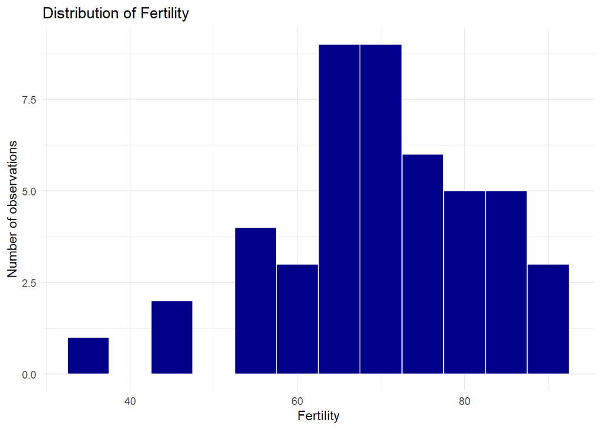

```r
ggplot(swiss_data, aes(x = Fertility)) +
  geom_histogram(binwidth = 5, fill = "darkblue", color = "white") +
  labs(title = "Distribution of Fertility",
       x = "Fertility", y = "Number of observations") +
  theme_minimal()
```

### Exercise j.5

- Create a boxplot of the variable `Education`

**Solution**

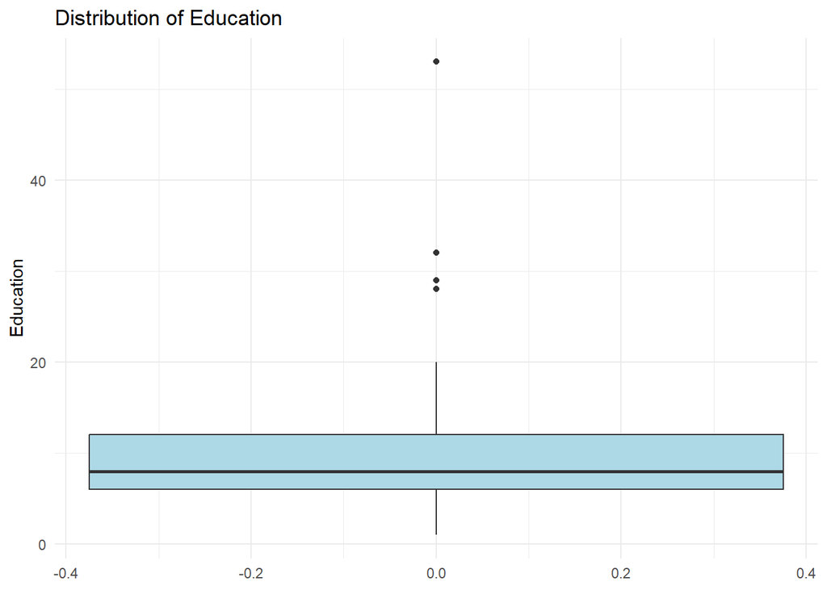

```r
ggplot(swiss_data, aes(y = Education)) +
  geom_boxplot(fill = "lightblue") +
  labs(title = "Distribution of Education", y = "Education") +
  theme_minimal()
```

### Exercise j.6

- Create a scatter plot of `Education` vs. `Fertility`
- Add a regression line (linear model)

**Solution**

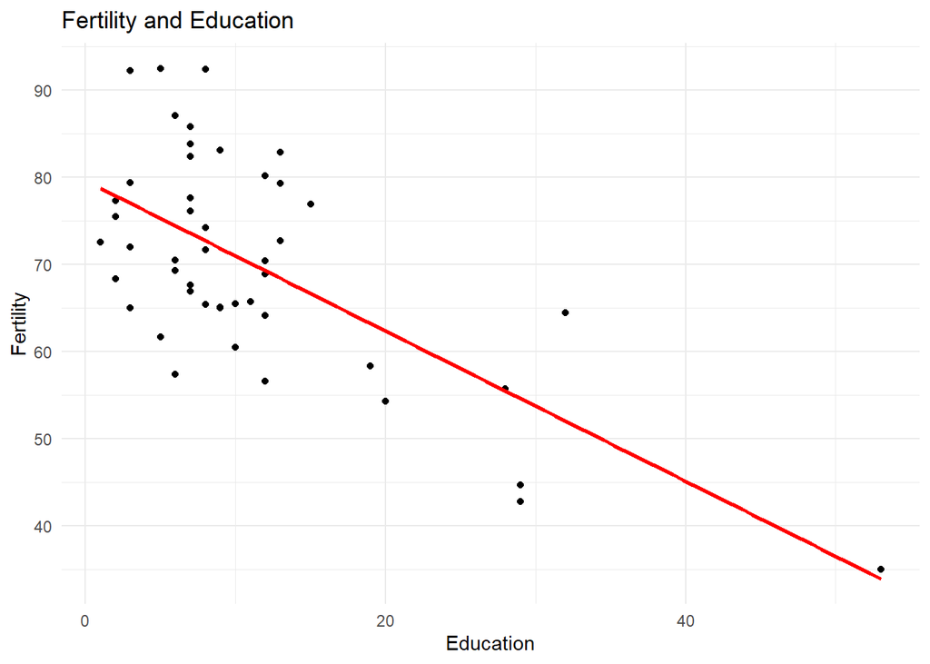

```r
ggplot(swiss_data, aes(x = Education, y = Fertility)) +
  geom_point() +
  geom_smooth(method = "lm", se = FALSE, color = "red") +
  labs(title = "Fertility and Education",
       x = "Education", y = "Fertility") +
  theme_minimal()
```

### Exercise j.7

- Create scatter plots of `Agriculture` vs. `Examination`
- Show them separately for each `FertilityCategory` using `facet_wrap()`

**Solution**

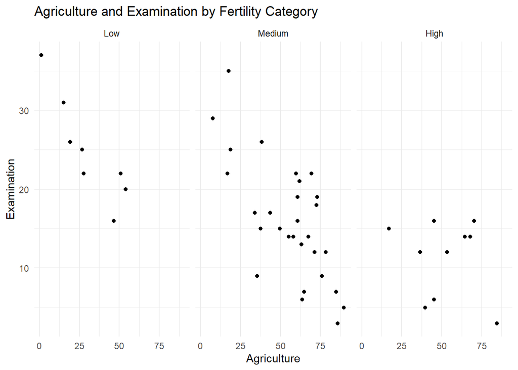

```r
ggplot(swiss_data, aes(x = Agriculture, y = Examination)) +
  geom_point() +
  facet_wrap(~ FertilityCategory) +
  labs(title = "Agriculture and Examination by Fertility Category",
       x = "Agriculture", y = "Examination") +
  theme_minimal()
```